# R Notebook

```r
library(tidyverse)
library(forcats)
```

```r
x <- c("Jan","Mar","Feb")
month_levels <- c(
  "Jan", "Feb", "Mar", "Apr", "May", "Jun",
  "Jul", "Aug", "Sep", "Oct", "Nov", "Dec"
)
y <- factor(x, levels = month_levels)
sort(y)
```

```
[1] Jan Feb Mar
Levels: Jan Feb Mar Apr May Jun Jul Aug Sep Oct Nov Dec
```

```r
gss_cat
```

| year | marital | age | race | rincome | partyid | relig | denom | tvhours |
| --- | --- | --- | --- | --- | --- | --- | --- | --- |
| 2000 | Never married | 26 | White | $8000 to 9999 | Ind,near rep | Protestant | Southern baptist | 12 |
| 2000 | Divorced | 48 | White | $8000 to 9999 | Not str republican | Protestant | Baptist-dk which | NA |
| 2000 | Widowed | 67 | White | Not applicable | Independent | Protestant | No denomination | 2 |
| 2000 | Never married | 39 | White | Not applicable | Ind,near rep | Orthodox-christian | Not applicable | 4 |
| 2000 | Divorced | 25 | White | Not applicable | Not str democrat | None | Not applicable | 1 |
| 2000 | Married | 25 | White | $20000 - 24999 | Strong democrat | Protestant | Southern baptist | NA |
| 2000 | Never married | 36 | White | $25000 or more | Not str republican | Christian | Not applicable | 3 |
| 2000 | Divorced | 44 | White | $7000 to 7999 | Ind,near dem | Protestant | Lutheran-mo synod | NA |
| 2000 | Married | 44 | White | $25000 or more | Not str democrat | Protestant | Other | 0 |
| 2000 | Married | 47 | White | $25000 or more | Strong republican | Protestant | Southern baptist | 3 |

[output cut: 990 more lines]

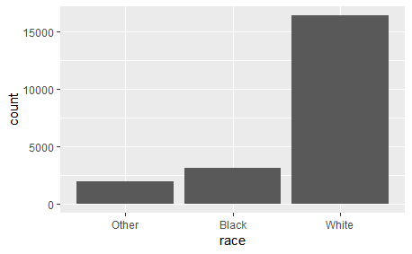

```r
gss_cat %>%
  ggplot(aes(race))+geom_bar()
```

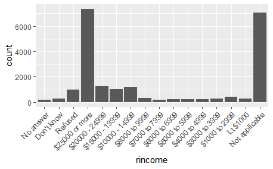

```r
gss_cat %>%
  ggplot(aes(rincome))+geom_bar()+
   theme(axis.text.x = element_text(angle = 45, hjust = 1))
```

I could improve this chart by fixing the orientation of the x axis labels

```r
gss_cat %>% count(relig)
```

| relig | n |
| --- | --- |
| No answer | 93 |
| Don't know | 15 |
| Inter-nondenominational | 109 |
| Native american | 23 |
| Christian | 689 |
| Orthodox-christian | 95 |
| Moslem/islam | 104 |
| Other eastern | 32 |
| Hinduism | 71 |
| Buddhism | 147 |

[output cut: 5 more lines]

Most common religion is protestant

```r
gss_cat %>% count(partyid)
```

| partyid | n |
| --- | --- |
| No answer | 154 |
| Don't know | 1 |
| Other party | 393 |
| Strong republican | 2314 |
| Not str republican | 3032 |
| Ind,near rep | 1791 |
| Independent | 4119 |
| Ind,near dem | 2499 |
| Not str democrat | 3690 |
| Strong democrat | 3490 |

```r
gss_cat %>%
  select(relig,denom) %>%
  filter(relig != "Protestant")
```

| relig | denom |
| --- | --- |
| Orthodox-christian | Not applicable |
| None | Not applicable |
| Christian | Not applicable |
| None | Not applicable |
| None | Not applicable |
| Jewish | Not applicable |
| None | Not applicable |
| Catholic | Not applicable |
| Catholic | Not applicable |
| None | Not applicable |

[output cut: 990 more lines]

denom applies to protestant, in the table u can see that for any non protestant relig, denom is not applicable

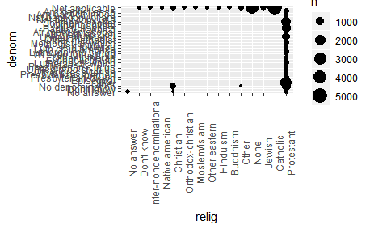

```r
gss_cat %>%
  count(relig, denom) %>%
  ggplot(aes(x = relig, y = denom, size = n)) +
  geom_point() +
  theme(axis.text.x = element_text(angle = 90))
```

15.4

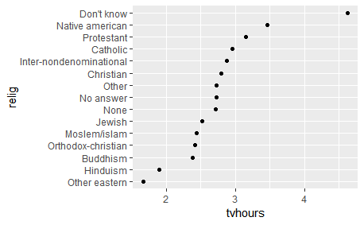

```r
relig_summary <- gss_cat %>%
  group_by(relig) %>%
  summarise(
    age = mean(age, na.rm = TRUE),
    tvhours = mean(tvhours, na.rm = TRUE),
    n = n()
  )
relig_summary %>%
  mutate(relig = fct_reorder(relig, tvhours)) %>%
  ggplot(aes(tvhours, relig)) +
    geom_point()
```

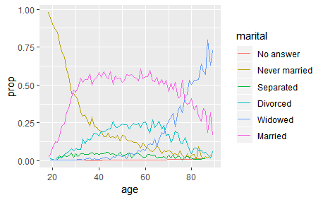

```r
by_age <- gss_cat %>%
  filter(!is.na(age)) %>%
  count(age, marital) %>%
  group_by(age) %>%
  mutate(prop = n / sum(n))
ggplot(by_age, aes(age, prop, colour = marital)) +
  geom_line(na.rm = TRUE)
```

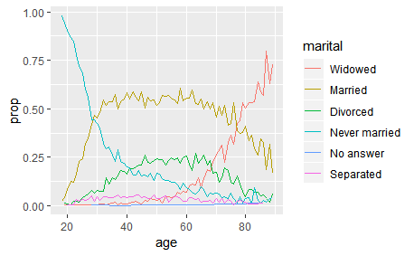

```r
ggplot(by_age, aes(age, prop, colour = fct_reorder2(marital, age, prop))) +
  geom_line() +
  labs(colour = "marital")
```

There are some suspiciously high numbers in tvhours. Is the mean a good summary?

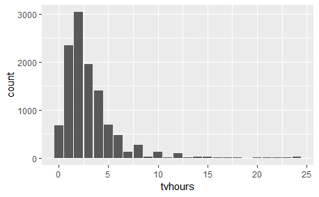

```r
gss_cat %>%
  ggplot(aes(tvhours))+geom_bar()
```

mean isn’t the worst but i think median would be better

For each factor in gss_cat identify whether the order of the levels is arbitrary or principled.

```r
gss_cat
```

| year | marital | age | race | rincome | partyid | relig | denom | tvhours |
| --- | --- | --- | --- | --- | --- | --- | --- | --- |
| 2000 | Never married | 26 | White | $8000 to 9999 | Ind,near rep | Protestant | Southern baptist | 12 |
| 2000 | Divorced | 48 | White | $8000 to 9999 | Not str republican | Protestant | Baptist-dk which | NA |
| 2000 | Widowed | 67 | White | Not applicable | Independent | Protestant | No denomination | 2 |
| 2000 | Never married | 39 | White | Not applicable | Ind,near rep | Orthodox-christian | Not applicable | 4 |
| 2000 | Divorced | 25 | White | Not applicable | Not str democrat | None | Not applicable | 1 |
| 2000 | Married | 25 | White | $20000 - 24999 | Strong democrat | Protestant | Southern baptist | NA |
| 2000 | Never married | 36 | White | $25000 or more | Not str republican | Christian | Not applicable | 3 |
| 2000 | Divorced | 44 | White | $7000 to 7999 | Ind,near dem | Protestant | Lutheran-mo synod | NA |
| 2000 | Married | 44 | White | $25000 or more | Not str democrat | Protestant | Other | 0 |
| 2000 | Married | 47 | White | $25000 or more | Strong republican | Protestant | Southern baptist | 3 |

[output cut: 990 more lines]

Why did moving “Not applicable” to the front of the levels move it to the bottom of the plot?

15.5 How have the proportions of people identifying as Democrat, Republican, and Independent changed over time?

[figure not shown]

```r
60/(684+1152+921)
```

```
[1] 0.02176279
```

How could you collapse rincome into a small set of categories?

Group all the small categories together, group the non responders and group the wealthy together as these factors are numerous but have low counts